# Lab assignment 4

Your name here

```r
library(tidyverse)
library(nycflights13)
```

# A different display of delays

Consider the `flights` dataset from the `nycflights13` dataset. In this exercise, you have to experiment with the `tile` geometric object (which you can access using the function `geom_tile`, for instance), which covers the plot with many small rectangles, one for each combination of values of `x` and `y`. We can leverage this to build a different visualization of the average delay for each day, with the fill color of each tile encoding the average delay. Complete the following code block.

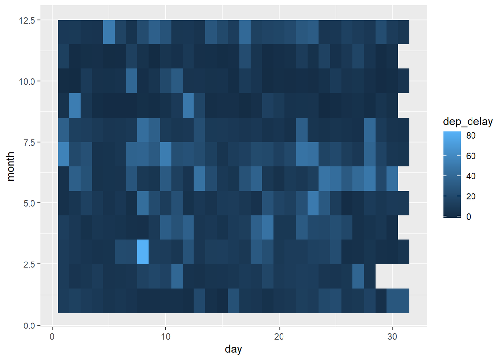

```r
# Map `day` to the `x` aesthetic, `month` to the `y` aesthetic and
# the average of `dep_delay` to the `fill` aesthetic

flights %>%
group_by(month, day) %>%
summarise(dep_delay = mean(dep_delay, na.rm=TRUE)) %>%
ggplot(aes(
        x=day, # Complete the aesthetic mapping
        y= month,
        fill=dep_delay
)) +
    geom_tile()
```

Now you should do the same without using the preprocessing pipeline. In particular, you should use a `stat_summary_2d` layer. Read the help page of `stat_summary_2d` to learn how to use the `x`, `y` and `z` aesthetic mappings to replicate the plot above. Note that since in this dataste months and days are encoded as numbers, but `stat_summary_2d` works best with discrete values, you will have to use `factor(month)` and `factor(day)` in your aesthetic mapping in place of `month` and `day`.

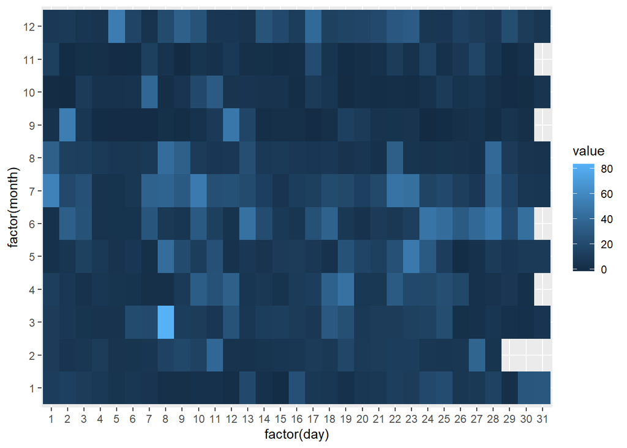

```r
 #Your solution here
flights %>%
drop_na()%>%
ggplot(aes(
      x=factor(day),
      y= factor(month),
      z=dep_delay
)) +
stat_summary_2d(aes(
  x=factor(day),
  y= factor(month),
  z=dep_delay
  )
)
```

```r
#ggplot(flights, aes(
  #     x=factor(day),
  #      y=factor(month),
 #       z = dep_delay
#)) +
#    stat_summary_2d()
```

# Experimental results analysis

In this exercise, you will play the role of a computer scientist comparing the running time of two different algorithms to multiply dense matrices, namely `naive` and `strassen`, for different sizes of their inputs. However, you don’t know if `naive` is faster than `strassen`. Therefore, you ran the following experiment: you consider values of the input size `n` in the set `2,4,8,16,32,64,128,256,512,1024,2048`. For each value of `n` each algorithm is run 10 times, recording the running time in nanoseconds. Therefore, you collect 10 different time measurements for input size 10 for `naive`, and 10 different time measurements for input size 10 for `strassen`.

The csv file `experiment.csv` contains the results of this experiment. You can load the data in this file using `read_csv("experiment.csv")`, there are no missing values. Your task in this exercise is to explore and visualize this experimental data, with the aim of answering the following question:

```r
library(readr)
experiment <- read_csv("experiment.csv")
View(experiment)
```

> Is `strassen` faster than `naive`?

After looking at the data with the `View` function, here are a few things you can try out:

- Plot using the `line` geom with the `time` on the `y` axis and `n` on the `x` axis. You can use `color` to distinguish between the two algorithms. Beware that for each value of `n` there are several measurements, so you might want to compute some summary statistic.

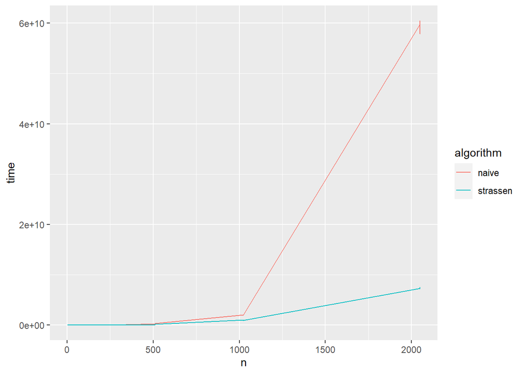

```r
experiment %>%
  ggplot(aes(x=n, y=time, color=algorithm))+
  geom_line()
```

- Try to add points on top of the lines, as a new layer.

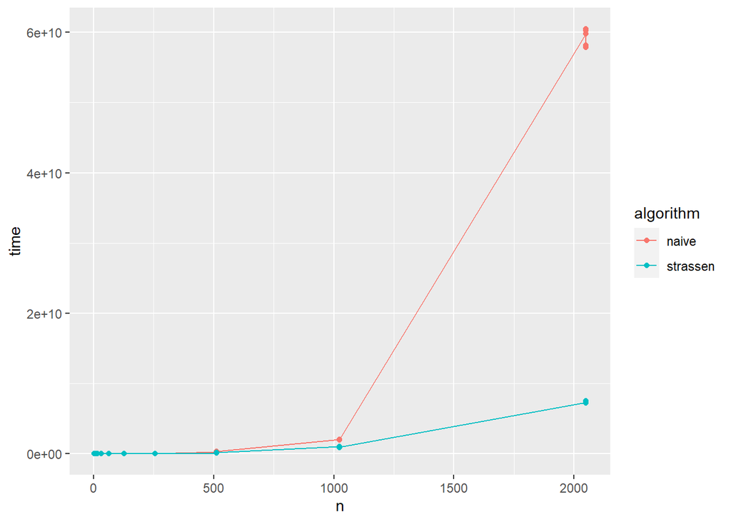

```r
experiment %>%
  ggplot(aes(x=n, y=time, color=algorithm))+
  geom_line()+geom_point()
```

- Use log scales on the `x` and `y` axis, possibly on both. For the `x` axis try to use a logarthmic scale in base 2, using `scale_x_continuous(trans="log2")`

```
## No summary function supplied, defaulting to `mean_se()`
## No summary function supplied, defaulting to `mean_se()`
```

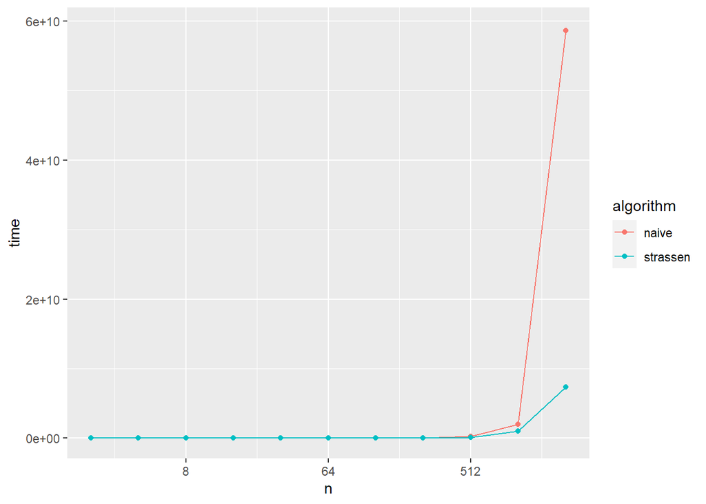

```r
experiment %>%
  ggplot(aes(x=n, y=time, color=algorithm))+
  geom_line(stat = "summary")+geom_point(stat = "summary")+
  scale_x_continuous(trans = "log2")
```

- Divide the time by the number of elements in the output matrix, which is `n^2`. This is like asking: how much time is each algorithm spending for each output value?

```
## No summary function supplied, defaulting to `mean_se()`
## No summary function supplied, defaulting to `mean_se()`
```

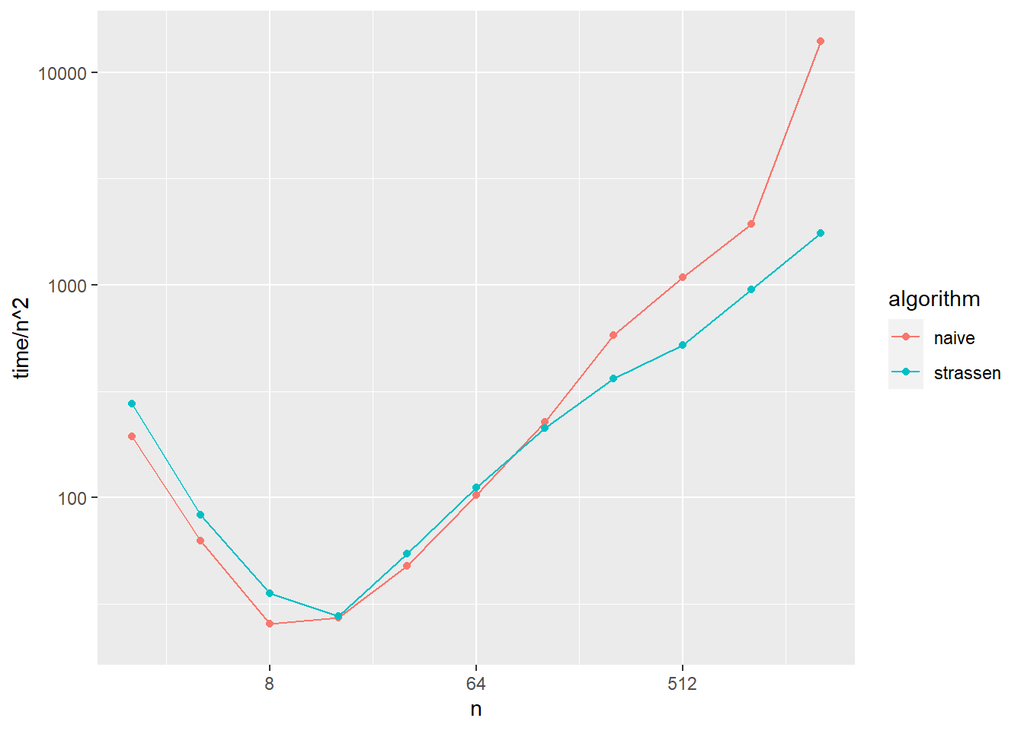

```r
experiment%>%
ggplot(aes(x = n, y = time / n^2, color = algorithm)) +
geom_line(stat = "summary") + geom_point(stat = "summary")+
scale_x_continuous(trans = "log2") +
scale_y_continuous(trans ="log10")
```

- Compute, for each value of `n`, the ratio between the average time of `naive` and the average time of `strassen`. You might need to use `pivot_wider` on the data before building the plot. Then, plot these ratios on the `y` axis and the value of `n` on the `x` axis. You can also add a horizontal line at ratio `1` using the layer `geom_hline(yintercept=1)` What is this plot displaying?

For each point in the list above create a new code block and write the code to create the plot following the hint.

```
## No summary function supplied, defaulting to `mean_se()`
## No summary function supplied, defaulting to `mean_se()`
```

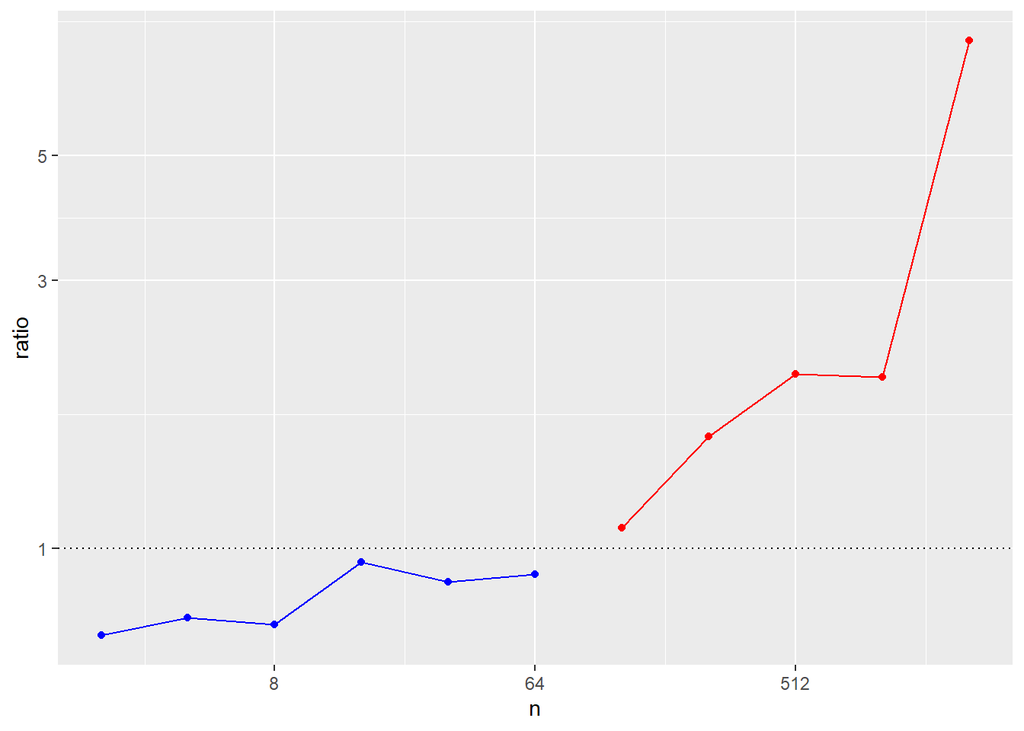

```r
experiment%>%
 group_by(algorithm, n)%>%
 summarise(time = mean(time))%>%
 pivot_wider(names_from = algorithm, values_from = time)%>%
 mutate(ratio = naive /strassen)%>%
 mutate(c = if_else(ratio <1, "blue", "red"))%>%

ggplot(experiment,mapping = aes(x = n, y = ratio, color = c)) +
 geom_line(stat = "summary") +
 geom_point(stat = "summary") +
 geom_hline(yintercept = 1, linetype = "dotted") +
 scale_color_identity() +
 scale_x_continuous(trans = "log2") +
 scale_y_continuous(trans ="log10")
```